# ADA 442 HomeWork

# Evaluate Model Performance

## *Comparison between Predicted Values and Test Data :*

*Has been made via Linear Regression :*

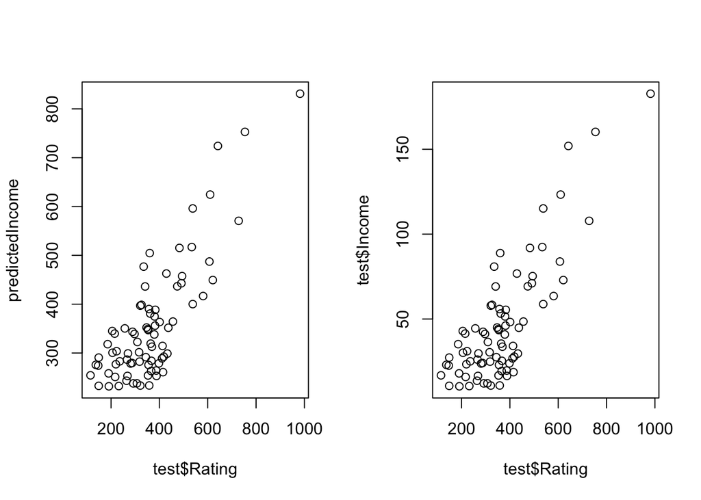

```r
predictedIncome <- predict(lm.fit, test)
par(mfrow = c(1,2))
plot(test$Rating, predictedIncome)
plot(test$Rating,test$Income)
```

```r
actuals_preds <- data.frame(cbind(actuals=test$Income, predicteds=predictedIncome))  # make actuals_predicteds dataframe.
correlation_accuracy <- cor(actuals_preds)
head(actuals_preds)
```

|  | actuals | predicteds |
| --- | --- | --- |
| 5 | 55.882 | 390.0519 |
| 10 | 71.061 | 442.8251 |
| 27 | 42.471 | 343.4256 |
| 30 | 26.813 | 288.9871 |
| 31 | 34.142 | 314.4680 |
| 36 | 23.350 | 276.9472 |

*Has been made via Multiple Linear Regression :*

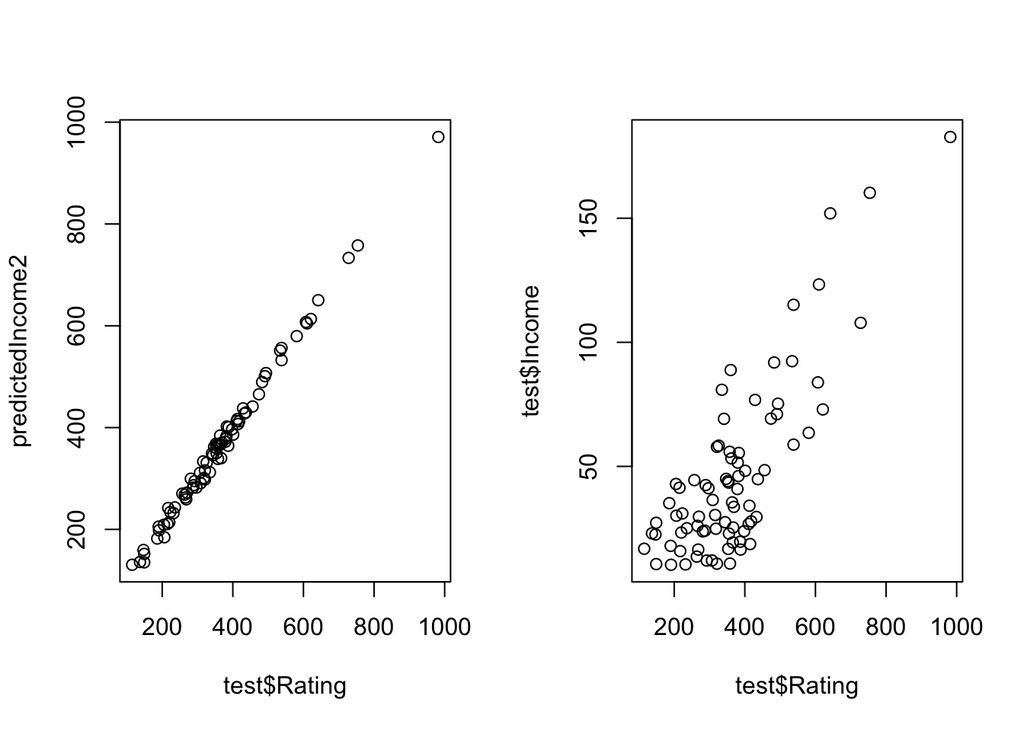

```r
predictedIncome2 <- predict(lm2.fit, test)
par(mfrow = c(1,2))
plot(test$Rating, predictedIncome2)
plot(test$Rating,test$Income)
```

```r
actuals_preds2 <- data.frame(cbind(actuals2=test$Income, predicteds2=predictedIncome2))  # make actuals_predicteds dataframe.
correlation_accuracy2 <- cor(actuals_preds2)
head(actuals_preds2)
```

|  | actuals2 | predicteds2 |
| --- | --- | --- |
| 5 | 55.882 | 364.0308 |
| 10 | 71.061 | 501.0350 |
| 27 | 42.471 | 286.8485 |
| 30 | 26.813 | 413.0004 |
| 31 | 34.142 | 416.7390 |
| 36 | 23.350 | 213.9380 |

Also, the most significant values to identify if a model well-explained are R^2 and adjusted R^2 values. R^2 values should be near 1. *Linear Regression :*

*Multiple Linear Regression :*

As seen above, Multiple LR Model can explain 99% of data. As a matter of fact, Multiple LR Model is better than Linear Regression Model. However, having such a high value of R^2 can be interpreted as over fitting. We might use validation to be more precise.

In addition, smallest residual standard error shows how well the model fits the data. Also, median should not be far from zero, and the minimum and maximum should be roughly equal in absolute value.

*Linear Regression :*

*Multiple Linear Regression :*

Despite, median of Linear Regression smaller than Multiple Linear Regression, Multiple Linear Regression offers more stable max/min values. As a result, Multiple LR Model fits better.

Moreover, higher F-Statistic value is better because F-statistics are measures of goodness of fit in terms of errors.

*Linear Regression :*

*Multiple Linear Regression :*

So, Multiple LR better here too.

Lastly, A standard way to test if the predictors are not meaningful is looking if the p-values smaller than 0.05.

*Linear Regression :*

- p-value: < 2.2e-16

*Multiple Linear Regression :*

- p-value: < 2.2e-16

Both of the models are meaningful.

```r
library(performance)

compare_performance(lm.fit, lm2.fit, rank = TRUE)
```

| Name | Model | R2 | R2_adjusted | RMSE | Sigma | AIC_wt | BIC_wt | Performance_Score |
| --- | --- | --- | --- | --- | --- | --- | --- | --- |
| lm2.fit | lm | 0.9940323 | 0.9939757 | 12.03594 | 12.11188 | 1.000000e+00 | 1.000000e+00 | 1 |
| lm.fit | lm | 0.6199888 | 0.6187938 | 96.04521 | 96.34677 | 1.698204e-288 | 7.354463e-287 | 0 |

As Final, Comparison of Model Performance Indices show us ultimate model that we can rely on.

# Conclusions

# References

- Lecture Slides
- https://online.stat.psu.edu/stat462/node/117/#:~:text=When%20conducting%20a%20residual%20analysis,unequal%20error%20variances%2C%20and%20outliers.
- https://towardsdatascience.com/q-q-plots-explained-5aa8495426c0
- https://www.statology.org/residuals-vs-leverage-plot/
- https://www.datacamp.com/community/tutorials/linear-regression-R
- https://towardsdatascience.com/back-to-basics-linear-regression-in-r-3ffe4900482b
- http://www.sthda.com/english/articles/40-regression-analysis/167-simple-linear-regression-in-r/
- https://www.statology.org/scale-location-plot/
- https://www.statology.org/residuals-vs-leverage-plot/
- https://www.machinelearningplus.com/machine-learning/complete-introduction-linear-regression-r/